# Decision Trees

Dr. Cong Zhang

*This document primarily refers to "Hands-on Machine Learning" chatper 6*

Decision Trees can perform both classification and regression tasks, and even multioutput tasks. They are powerful algorithms, capable of fitting complex datasets.

In this document we will start by discussing how to train, visualize, and make predictions with Decision Trees. Then we will go through the CART training algorithm used by Scikit-Learn, and we will discuss how to regularize trees and use them for regression tasks.

## Training and Visualizing a Decision Tree

Let's first build a decision tree and take a look at how it makes predictions. The following cell trains a *DecisionTreeClassifier* on the iris dataset. The iris dataset has four attributes: sepal length, sepal width, petal length, and petal width. The three types of iris are: setosa, veriscolor, and virginica. Let's try to use the four attributes to identify the species for the iris.

```python
# Load the built-in iris data.
from sklearn.model_selection import train_test_split
from sklearn.datasets import load_iris
from sklearn.tree import DecisionTreeClassifier
# Store the dataset as "iris".
iris = load_iris()
# Predictors
X = iris.data
# Targets
y = iris.target
# Randomly sample our data --> 70% to train with, and 30% for testing
X_train, X_test, y_train, y_test = train_test_split(X, y, test_size=0.3)
# Build a decision tree model and set the maximum depth to be two.
tree_clf = DecisionTreeClassifier(max_depth=2)
# Train the model
tree_clf.fit(X_train, y_train)
```

```
DecisionTreeClassifier(max_depth=2)
```

We can visualize the trained decision tree by using the *plot_tree* method:

[output not shown]

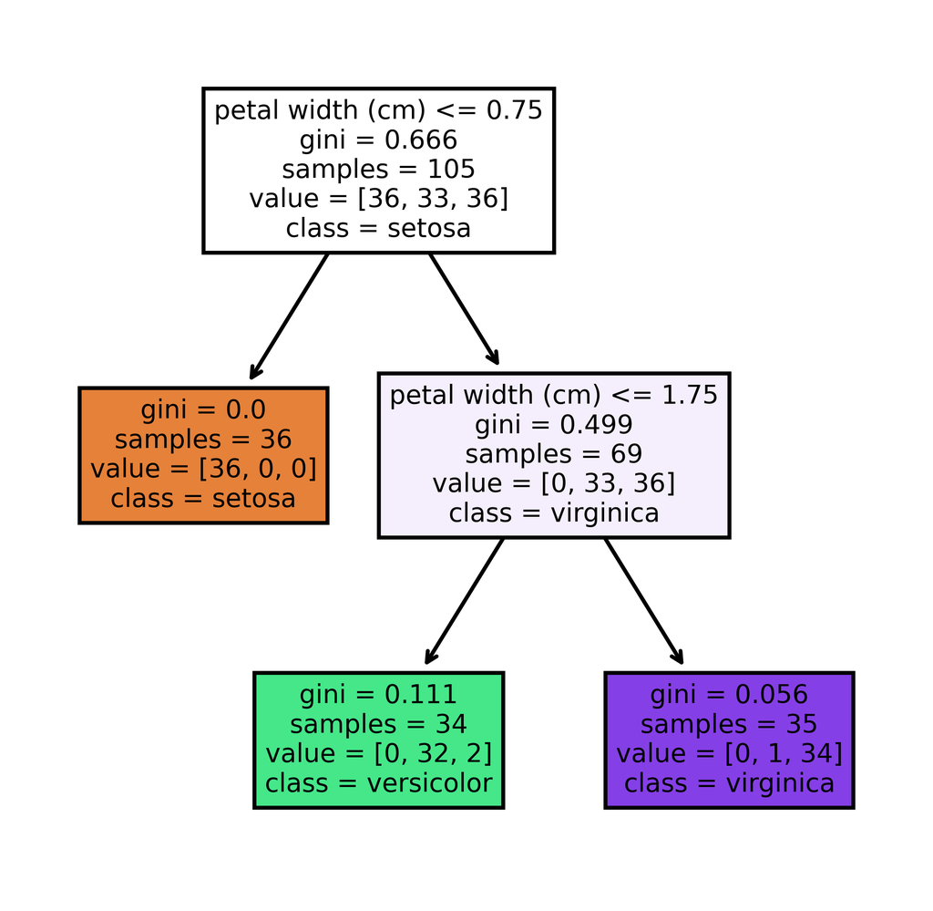

```python
from sklearn import tree
import matplotlib.pyplot as plt

fn=['sepal length (cm)','sepal width (cm)','petal length (cm)','petal width (cm)']
cn=['setosa', 'versicolor', 'virginica']

# Setting dpi = 300 to make image clearer than default
fig, axes = plt.subplots(nrows = 1,ncols = 1,figsize = (4,4), dpi=600)

tree.plot_tree(tree_clf, # Which model to plot
           feature_names = fn, # Variable names (in order!)
           class_names=cn, # Class names (in order!)
           filled = True) # Provides the color-filled cells
```

We can evaluate the performance of our trained model using the cross-validation like what we did perviously for the regression models. To keep it simple, we will use the classification accuracy as the performance measure for now. We will learn different performance measures for classificaiton problems in the future. The classification accuracy is the most straightforward measure. It is measured by the ratio of the number of correctly-grouped instances and the total instances. A 0.9 accuracy means 90% of the instances are correctly classified.

```python
from sklearn.model_selection import cross_val_score
#Start a 10-fold cross validation and store the accuracy scores in "scores".
scores = cross_val_score(tree_clf, X_train, y_train, cv = 10, scoring="accuracy")
print("The average accuracy score is:",scores.mean())
```

```
The average accuracy score is: 0.9618181818181819
```